# Omics

Author

Bio Data Science^3 faculty

Published

Invalid Date

# scRNA-seq analysis

## Preamble

### Dependencies

```r
# load required packages
library(dplyr)
library(scran)
library(scran)
library(scater)
library(igraph)
library(ggplot2)
library(muscData)
library(pheatmap)
library(ExperimentHub)
```

### Data retrieval

```r
eh <- ExperimentHub()
q <- query(eh, "Kang18")
(sce <- eh[[q$ah_id]])
```

```
class: SingleCellExperiment
dim: 35635 29065
metadata(0):
assays(1): counts
rownames(35635): MIR1302-10 FAM138A ... MT-ND6 MT-CYB
rowData names(2): ENSEMBL SYMBOL
colnames(29065): AAACATACAATGCC-1 AAACATACATTTCC-1 ... TTTGCATGGTTTGG-1
  TTTGCATGTCTTAC-1
colData names(5): ind stim cluster cell multiplets
reducedDimNames(1): TSNE
mainExpName: NULL
altExpNames(0):
```

## Preprocessing

### Quality control

```r
sce <- sce[rowSums(counts(sce) > 0) > 0, ]
sce <- addPerCellQC(sce)
sce <- sce[, !isOutlier(sce$detected, nmads=2, log=TRUE)]
sce <- sce[rowSums(counts(sce) > 1) >= 10, ]
```

### Feature selection

For each gene, we compute the variance and mean of the log-expression values. A trend is fitted to the variance against the mean for all genes. The fitted value for each gene is used as a proxy for the technical component of variation for each gene, under the assumption that most genes exhibit a low baseline level of variation that is not biologically interesting. The biological component of variation for each gene is defined as the the residual from the trend. (see `?modelGeneVar`)

```r
# log-library size normalization
sce <- logNormCounts(sce)
# model gene expr. mean vs. var.
df <- modelGeneVar(sce)
head(df)
```

```
DataFrame with 6 rows and 6 columns
              mean     total      tech        bio      p.value
         <numeric> <numeric> <numeric>  <numeric>    <numeric>
NOC2L    0.0696493 0.0819799 0.0775952 0.00438472  3.59549e-01
HES4     0.0982435 0.1261553 0.1088819 0.01727339  1.56308e-01
ISG15    2.1064758 4.6389017 1.0478233 3.59107844 8.60524e-106
TNFRSF18 0.0682297 0.1015325 0.0760317 0.02550081  1.63899e-02
TNFRSF4  0.0583023 0.0831188 0.0650732 0.01804558  3.87765e-02
SDF4     0.0792608 0.0918320 0.0881562 0.00367583  3.95352e-01
                                                                                                                   FDR
                                                                                                             <numeric>
NOC2L    0.74064798283870392214822686582920141518115997314453125000000000000000000000000000000000000000000000000000000
HES4     0.74064798283870392214822686582920141518115997314453125000000000000000000000000000000000000000000000000000000
ISG15    0.00000000000000000000000000000000000000000000000000000000000000000000000000000000000000000000000000000612521
TNFRSF18 0.69031499183241884498585250184987671673297882080078125000000000000000000000000000000000000000000000000000000
TNFRSF4  0.74064798283870392214822686582920141518115997314453125000000000000000000000000000000000000000000000000000000
SDF4     0.74064798283870392214822686582920141518115997314453125000000000000000000000000000000000000000000000000000000
```

> Use `dplyr` to filter the above gene-level statistics (`df`) for genes the 2,000 genes with the highest `bio`logical variance component.

The genes selected above correspond to genes with a large deviation from the baseline level of (technical) variation, i.e., they tend to have a large biological variance component:

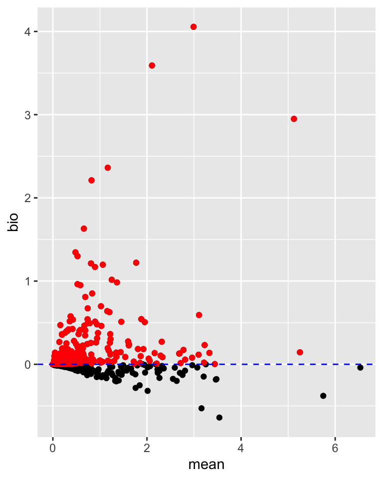

### Dimension reduction

In standard scRNA-seq data anlysis pipelines, these “highly variable features” are subjected to principal component analysis (PCA) in order to identify major axes of variation. We can perform PCA on a `SingleCellExperiment` using `runPCA()` (`scater` package), where we specify the subset of features to use via argument `subset_row`:

```r
# get selected features
length(sel <- rownames(fd))
```

```
[1] 2000
```

```r
# perform principal component analysis
sce <- runPCA(sce, subset_row=sel)
```

By default, `runPCA()` computes 50 PCs that are stored in the input object as a `reducedDim()` slot:

```r
# rows=cells, columns=PCs
pcs <- reducedDim(sce, "PCA")
pcs[1:5, 1:5]
```

```
                    PC1    PC2    PC3     PC4      PC5
AAACATACAATGCC-1 -7.557 -2.386 -1.414  2.0674  -1.4634
AAACATACATTTCC-1  8.666 -9.110 -2.272 -2.6015   1.8624
AAACATACCAGAAA-1 11.917 -9.813  2.073  1.4183  -1.6350
AAACATACCAGCTA-1  8.602 -9.003  1.269  2.5981  -0.4418
AAACATACCATGCA-1  0.302 -2.382  5.205 -0.7592 -11.3635
```

```r
dim(pcs)
```

```
[1] 26820    50
```

> Generate a scatter plot of PCs 1 and 2 with cells colored by log-library size. Taking into consideration the plots generated above, what is the main driver of gene expression variation (PC1)?

- color cells by gene expression (`logcounts()`)
- plot PCs (linear) again t-SNE dimensions (non-linear)
- `facet_wrap()` by `stim/ind/cell` to split plots according to some metadata variable